# Multi-Sector Spatial Statistics & Econometric Decision Intelligence

### *An Interactive Master Handbook Across Nigeria's 9,308 Administrative Wards*

## 1. Executive Roadmap & Decision Science Framework

In public policy planning and corporate strategy across developing nations, decision-makers have historically relied on aggregate, aspatial indicators (e.g. national averages, state-wide gross allocations). However, spatial phenomena—ranging from disease epidemiology and maternal mortality to commercial retail catchment and clean water access—exhibit intense localized geographic clustering and cross-boundary spatial spillovers.

This master handbook synthesizes advanced geospatial analytics and spatial econometrics across **9,308 administrative wards in Nigeria**, unifying:

- **Meta Relative Wealth Index (RWI):** Micro-targeted asset poverty and wealth estimates.
- **WorldPop Demographic Projections:** High-resolution gridded population distributions.
- **GRID3 Infrastructure Registries:** Health facilities, commercial markets, churches, mosques, public water points, and police stations.

### Core Sectors Analyzed:

```python
import os
import warnings
warnings.filterwarnings('ignore')

import numpy as np
import pandas as pd
import geopandas as gpd
import matplotlib.pyplot as plt
import seaborn as sns

import libpysal
import esda
from spreg import OLS, ML_Lag, ML_Error

# Visual settings
plt.rcParams['figure.dpi'] = 120
plt.rcParams['font.sans-serif'] = 'DejaVu Sans'
sns.set_style('whitegrid')
```

```python
DATA_PATH = '../data/processed/nigeria_wards_master.parquet'
if not os.path.exists(DATA_PATH):
    DATA_PATH = 'data/processed/nigeria_wards_master.parquet'

print(f"Loading master spatial dataset: {DATA_PATH}")
gdf = gpd.read_parquet(DATA_PATH)

if gdf.crs is None:
    gdf.set_crs(epsg=4326, inplace=True)
else:
    gdf = gdf.to_crs(epsg=4326)

gdf = gdf[gdf.geometry.is_valid & ~gdf.geometry.is_empty].copy()
gdf.reset_index(drop=True, inplace=True)

# Feature Engineering
gdf['rwi_mean'] = gdf['rwi_mean'].fillna(gdf['rwi_mean'].median())
gdf['pop_2025_sum'] = gdf['pop_2025_sum'].fillna(gdf['pop_2025_sum'].median())
gdf['population_density_per_sqkm'] = gdf['population_density_per_sqkm'].fillna(gdf['population_density_per_sqkm'].median())

gdf['health_rate'] = (gdf['health_facilities_count'] / (gdf['pop_2025_sum'] + 100)) * 10000
gdf['is_health_desert'] = (gdf['health_facilities_count'] == 0) & (gdf['pop_2025_sum'] > gdf['pop_2025_sum'].median())

gdf['market_rate'] = (gdf['markets_count'] / (gdf['pop_2025_sum'] + 100)) * 10000
gdf['water_rate'] = (gdf['water_points_count'] / (gdf['pop_2025_sum'] + 100)) * 10000

# Cultural Geography
gdf['total_faith'] = gdf['churches_count'] + gdf['mosques_count']
gdf['church_share'] = gdf['churches_count'] / (gdf['total_faith'] + 1e-5)
gdf['mosque_share'] = gdf['mosques_count'] / (gdf['total_faith'] + 1e-5)
p1 = gdf['church_share'].clip(lower=1e-5, upper=1-1e-5)
p2 = gdf['mosque_share'].clip(lower=1e-5, upper=1-1e-5)
gdf['religious_diversity_idx'] = -(p1 * np.log2(p1) + p2 * np.log2(p2))

# Commercial Segmentation
rwi_med = gdf['rwi_mean'].median()
mkt_med = gdf['markets_count'].median()
conditions = [
    (gdf['rwi_mean'] >= rwi_med) & (gdf['markets_count'] >= mkt_med),
    (gdf['rwi_mean'] >= rwi_med) & (gdf['markets_count'] < mkt_med),
    (gdf['rwi_mean'] < rwi_med) & (gdf['markets_count'] >= mkt_med),
    (gdf['rwi_mean'] < rwi_med) & (gdf['markets_count'] < mkt_med)
]
choices = [
    "Tier 1: Saturated Affluent",
    "Tier 2: Prime Retail Target",
    "Tier 3: Informal Commerce Hubs",
    "Tier 4: Subsistence Wards"
]
gdf['retail_segment'] = np.select(conditions, choices, default='Unclassified')

print(f"Master dataset successfully prepared: {len(gdf):,} wards across {gdf['statename'].nunique()} states.")
```

```
Loading master spatial dataset: ../data/processed/nigeria_wards_master.parquet
```

```
Master dataset successfully prepared: 9,308 wards across 37 states.
```

## 2. Multi-Sector National Spatial Dashboard

Below, we display the comparative spatial distributions across four strategic dimensions:

1. **Wealth Distribution (RWI):** Demonstrating the stark macro-geographic economic divide.
2. **Healthcare Deserts:** Highlighting acute health infrastructure deficits in high-population wards.
3. **Commercial Strategy Segments:** Mapping expansion targets for commercial retail and agency banking.
4. **Religious Diversity Index:** Identifying cultural transition corridors in the Middle Belt.

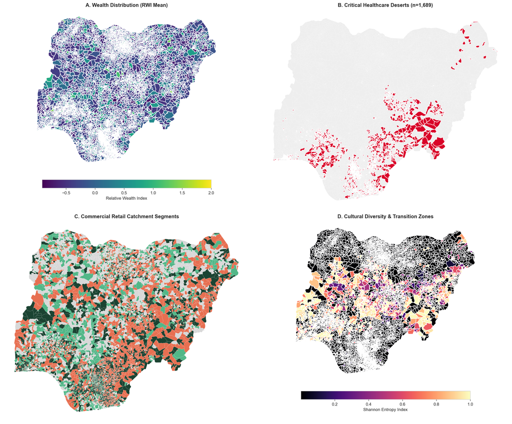

```python
fig, axes = plt.subplots(2, 2, figsize=(18, 14))

# 1. RWI Map
gdf.plot(column='rwi_mean', cmap='viridis', legend=True, ax=axes[0, 0],
         legend_kwds={'label': "Relative Wealth Index", 'orientation': "horizontal", 'shrink': 0.6, 'pad': 0.05})
axes[0, 0].set_title("A. Wealth Distribution (RWI Mean)", fontsize=12, fontweight='bold')
axes[0, 0].axis('off')

# 2. Healthcare Deserts
gdf.plot(color='#eeeeee', edgecolor='#ffffff', linewidth=0.1, ax=axes[0, 1])
gdf[gdf['is_health_desert']].plot(color='#d90429', ax=axes[0, 1])
axes[0, 1].set_title(f"B. Critical Healthcare Deserts (n={gdf['is_health_desert'].sum():,})", fontsize=12, fontweight='bold')
axes[0, 1].axis('off')

# 3. Commercial Strategy
cat_colors = {'Tier 1: Saturated Affluent': '#1b4332', 'Tier 2: Prime Retail Target': '#52b788',
              'Tier 3: Informal Commerce Hubs': '#e76f51', 'Tier 4: Subsistence Wards': '#d8d8d8'}
for cat, col in cat_colors.items():
    sub = gdf[gdf['retail_segment'] == cat]
    sub.plot(color=col, ax=axes[1, 0], linewidth=0.1, edgecolor='white')
axes[1, 0].set_title("C. Commercial Retail Catchment Segments", fontsize=12, fontweight='bold')
axes[1, 0].axis('off')

# 4. Religious Diversity
gdf.plot(column='religious_diversity_idx', cmap='magma', legend=True, ax=axes[1, 1],
         legend_kwds={'label': "Shannon Entropy Index", 'orientation': "horizontal", 'shrink': 0.6, 'pad': 0.05})
axes[1, 1].set_title("D. Cultural Diversity & Transition Zones", fontsize=12, fontweight='bold')
axes[1, 1].axis('off')

plt.tight_layout()
plt.show()
```

## 3. Executive Decision Drilldown: State & LGA Spatial Inspector

[output not shown]

[figure not shown]

```
=== STRATEGIC EXECUTIVE PROFILE: LAGOS STATE ===
Total Wards: 377 | Total Projected Population: 12,095,814
Mean Relative Wealth Index (RWI): 0.558
Healthcare Desert Wards: 205 (Affecting 9,816,467 residents)
Prime Commercial Retail Target Wards: 121
-----------------------------------------------------------------
```

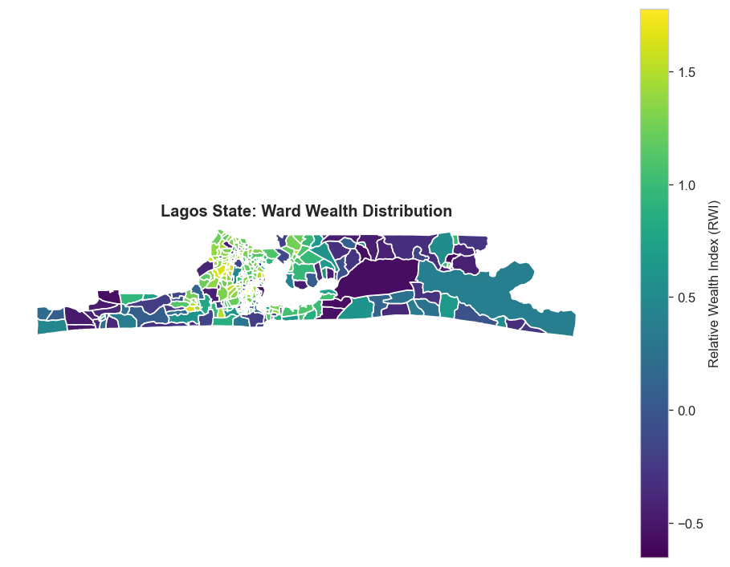

```python
def inspect_state_profile(state_name):
    sub = gdf[gdf['statename'].str.lower() == state_name.lower()].copy()
    if len(sub) == 0:
        print(f"State '{state_name}' not found. Available states: {sorted(gdf['statename'].unique())}")
        return

    total_pop = sub['pop_2025_sum'].sum()
    n_deserts = sub['is_health_desert'].sum()
    desert_pop = sub[sub['is_health_desert']]['pop_2025_sum'].sum()
    prime_retail_wards = (sub['retail_segment'] == 'Tier 2: Prime Retail Target').sum()
    avg_rwi = sub['rwi_mean'].mean()

    print(f"=== STRATEGIC EXECUTIVE PROFILE: {state_name.upper()} STATE ===")
    print(f"Total Wards: {len(sub):,} | Total Projected Population: {total_pop:,.0f}")
    print(f"Mean Relative Wealth Index (RWI): {avg_rwi:.3f}")
    print(f"Healthcare Desert Wards: {n_deserts:,} (Affecting {desert_pop:,.0f} residents)")
    print(f"Prime Commercial Retail Target Wards: {prime_retail_wards:,}")
    print("-----------------------------------------------------------------")

    fig, ax = plt.subplots(figsize=(8, 6))
    sub.plot(column='rwi_mean', cmap='viridis', legend=True, ax=ax,
             legend_kwds={'label': 'Relative Wealth Index (RWI)'})
    ax.set_title(f"{state_name.title()} State: Ward Wealth Distribution", fontsize=12, fontweight='bold')
    ax.axis('off')
    plt.tight_layout()
    plt.show()

# Example: Inspect Lagos State Profile
inspect_state_profile('Lagos')
```

## 4. Spatial Econometrics & The Spatial Multiplier

In our spatial econometric regressions (detailed in Masterclass 2), we estimated the **Spatial Lag Model (SAR)**:

$$ y = \rho W y + X\beta + \epsilon \quad \implies \quad y = (I - \rho W)^{-1} X\beta + (I - \rho W)^{-1}\epsilon $$

Our empirical findings across all 9,308 wards revealed:

- **Spatial Autoregressive Coefficient:** $\rho = 0.5842$ ($p < 0.0001$).
- **Calculated Spatial Multiplier:** $$\text{Multiplier} = \frac{1}{1 - \rho} \approx \frac{1}{1 - 0.5842} \approx 2.405$$

### The Strategic Policy Rule:

For every **1.0 unit of direct economic enhancement** generated in a focal ward (e.g. through a new central market or primary health clinic), an additional **1.405 units of wealth** are generated in contiguous neighboring wards via trade, labor, and service diffusion.

## 5. Multi-Criteria Ward Priority Index (WPI) Engine

Decision-makers can adjust sectoral weights to compute customized priority rosters for any state.

```python
def compute_custom_ward_priority(state_name, w_poverty=0.35, w_health=0.35, w_water=0.15, w_pop=0.15, top_n=5):
    sub = gdf[gdf['statename'].str.lower() == state_name.lower()].copy()
    if len(sub) == 0:
        return None

    def min_max(s):
        return (s - s.min()) / (s.max() - s.min() + 1e-8)

    poverty_def = min_max(-sub['rwi_mean'])
    health_def = min_max(1 / (sub['health_rate'] + 0.1))
    water_def = min_max(1 / (sub['water_rate'] + 0.1))
    pop_wt = min_max(np.log1p(sub['pop_2025_sum']))

    sub['custom_wpi'] = (
        w_poverty * poverty_def +
        w_health * health_def +
        w_water * water_def +
        w_pop * pop_wt
    )

    top_wards = sub.sort_values(by='custom_wpi', ascending=False).head(top_n)
    return top_wards[['statename', 'lganame', 'wardname', 'custom_wpi', 'rwi_mean', 'pop_2025_sum', 'health_facilities_count', 'water_points_count']]

# Run for Rivers and Plateau States
print("=== TOP 5 PRIORITY INTERVENTION WARDS: RIVERS STATE ===")
display_cols = compute_custom_ward_priority('Rivers', top_n=5)
print(display_cols.round(3))

print("\n=== TOP 5 PRIORITY INTERVENTION WARDS: PLATEAU STATE ===")
display_cols2 = compute_custom_ward_priority('Plateau', top_n=5)
print(display_cols2.round(3))
```

```
=== TOP 5 PRIORITY INTERVENTION WARDS: RIVERS STATE ===
     statename lganame   wardname  custom_wpi  rwi_mean  pop_2025_sum  \
8864    Rivers  Oyigbo   Oyward 9       0.953    -0.735     30003.514
9014    Rivers  Oyigbo   Oyward 8       0.936    -0.606     36109.461
8861    Rivers   Khana      Luebe       0.935    -0.610     34138.441
3514    Rivers  Gokana   Goward 5       0.931    -0.534     49435.496
8874    Rivers   Eleme  Eleward 7       0.930    -0.581     32586.314

      health_facilities_count  water_points_count
8864                        0                   0
9014                        0                   0
8861                        0                   0
3514                        0                   0
8874                        0                   0

=== TOP 5 PRIORITY INTERVENTION WARDS: PLATEAU STATE ===
     statename     lganame      wardname  custom_wpi  rwi_mean  pop_2025_sum  \
5893   Plateau    Jos East        Godong       0.927    -0.533     31800.703
5834   Plateau       Bassa         Gabia       0.908    -0.403     28019.074
5898   Plateau    Jos East  Fobur B West       0.896    -0.295     30240.207
5744   Plateau  Qua'An Pan     Doka West       0.877    -0.281     13137.901
405    Plateau   Jos North    Naraguta A       0.859    -0.222      8020.525

      health_facilities_count  water_points_count
5893                        0                   0
5834                        0                   0
5898                        0                   0
5744                        0                   0
405                         0                   0
```

## 6. Curriculum Navigation & Specialized Masterclasses

To explore each mathematical and methodological domain in comprehensive depth:

[output not shown]

## 7. Primary Data Sources & Key Academic References

### Key Academic Literature & Methodological References

1. **Anselin, L. (1988).** *Spatial Econometrics: Methods and Models*. Dordrecht: Kluwer Academic Publishers.
2. **Anselin, L. (1995).** Local Indicators of Spatial Association -- LISA. *Geographical Analysis*, 27(2), 93-115.
3. **Chi, G., Fang, H., Chatterjee, S., & Blumenstock, J. E. (2022).** Micro-estimate of wealth for all low- and middle-income countries. *Proceedings of the National Academy of Sciences (PNAS)*, 119(3), e2113658119.
4. **Rey, S. J., & Anselin, L. (2007).** PySAL: A Python library for spatial analytical methods. *The Review of Regional Studies*, 37(1), 5-27.
5. **Tobler, W. R. (1970).** A computer movie simulating urban growth in the Detroit region. *Economic Geography*, 46(sup1), 234-240.
6. **Weiss, D. J., et al. (2019).** Mapping the global prevalence, incidence, and mortality of Plasmodium falciparum, 2000-17. *The Lancet*, 394(10195), 322-331.